# SemiaridClimate_pt2

**Note:** The databases used and the codes can be found in my GitHub repository:

https://github.com/willneto/Semiarid

## Semiarid Climate (part 2)

- First, import this database.
- Second, we will import shapefile data (geographic information) of the SUDENE region.
- Third, we will use an interpolation technique to fill all cities with climate indicators information.
- Finally, we will plot maps to show the areas with more semiarid conditions.

When solving these tasks, we believe it to be possible to learn more about the geopandas package and an interpolation technique.

**Libraries**

```python
import geopandas as gpd
import pandas as pd
import numpy as np
import matplotlib.pyplot as plt
from shapely.geometry import Point, Polygon, LineString
import datetime
```

## Importing to database with indicators

```python
#Importing
df_indicators = pd.read_csv("indicators_81_2010.csv")
```

```python
#Index
df_indicators = df_indicators.set_index('index')
```

```python
#Result!
df_indicators.head()
```

| index | MEDIA_PREC_ANUAL | Aridity Index | dias_s_chuv | latitude | longitude |
| --- | --- | --- | --- | --- | --- |
| 82024 | 1857.982759 | 1.067662 | 229.263158 | 2.829444 | -60.661944 |
| 82042 | 2294.330000 | 1.285756 | 207.800000 | 1.832500 | -61.120833 |
| 82098 | 2538.106667 | 1.449600 | 170.400000 | -0.045000 | -51.110000 |
| 82106 | 3060.840000 | 1.937485 | 129.941176 | -0.125278 | -67.061111 |
| 82113 | 2492.100000 | 1.432446 | 154.666667 | -0.974167 | -62.928611 |

## Importing geographic information

- Shapefile of the SUDENE region.

```python
#Importing
sudene_geo_info = gpd.read_file("LIM_Sudene_Municipal_2018/LIM_Sudene_Municipal_2018.shp",encoding= 'ISO-8859-1')
```

```python
#See the DF!
sudene_geo_info.head()
```

|  | NM_MUNICIP | CD_GEOCMU | CD_GEOCMU6 | UF | SEMIARIDO | Pop_Est_18 | geometry |
| --- | --- | --- | --- | --- | --- | --- | --- |
| 0 | RAPOSA | 2109452 | 210945 | MA | NÃO | 30337 | MULTIPOLYGON (((-44.02026 -2.40732, -44.02157 ... |
| 1 | HELIÓPOLIS | 2911857 | 291185 | BA | SIM | 13076 | POLYGON ((-38.25666 -10.69420, -38.24629 -10.7... |
| 2 | ABAIARA | 2300101 | 230010 | CE | SIM | 11663 | POLYGON ((-39.01733 -7.30238, -39.01707 -7.302... |
| 3 | RECIFE | 2611606 | 261160 | PE | NÃO | 1637834 | POLYGON ((-34.99971 -7.92977, -34.99953 -7.929... |
| 4 | ABAÍRA | 2900108 | 290010 | BA | SIM | 8767 | POLYGON ((-41.64722 -13.17888, -41.64679 -13.1... |

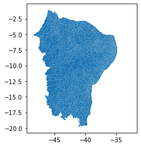

```python
#See the map!
sudene_geo_info.plot()
```

```python
##Let's delete some unnecessary information in DF
sudene_geo_info = sudene_geo_info.drop("CD_GEOCMU,CD_GEOCMU6,UF,SEMIARIDO,Pop_Est_18".split(","),axis=1)
```

**Let's create points to locate each weather station.**

```python
#Empty column that will receive the information
df_indicators["geometry"] = ''
```

We will use a loop for cycling through each station in our data frame. We will use the latitude and longitude information to create data in "Point" format - this way, the geopandas package will be able to interact with this information.

```python
for index in df_indicators.index:

    #Passing the information to the DF
    df_indicators.loc[index,"geometry"] = Point([df_indicators.loc[index,"longitude"],
                                                 df_indicators.loc[index,"latitude"]])
```

```python
##Result!
df_indicators.head()
```

| index | MEDIA_PREC_ANUAL | Aridity Index | dias_s_chuv | latitude | longitude | geometry |
| --- | --- | --- | --- | --- | --- | --- |
| 82024 | 1857.982759 | 1.067662 | 229.263158 | 2.829444 | -60.661944 | POINT (-60.66194444 2.82944443) |
| 82042 | 2294.330000 | 1.285756 | 207.800000 | 1.832500 | -61.120833 | POINT (-61.12083332 1.83249999) |
| 82098 | 2538.106667 | 1.449600 | 170.400000 | -0.045000 | -51.110000 | POINT (-51.11 -0.04499999) |
| 82106 | 3060.840000 | 1.937485 | 129.941176 | -0.125278 | -67.061111 | POINT (-67.06111111 -0.12527777) |
| 82113 | 2492.100000 | 1.432446 | 154.666667 | -0.974167 | -62.928611 | POINT (-62.9286111 -0.97416666) |

**Now we will use "df_indicators" to create a GeoDataFrame.**

```python
geodf_indicators = gpd.GeoDataFrame(df_indicators,crs="EPSG:4326")
```

## Map of the SUDENE region + weather stations

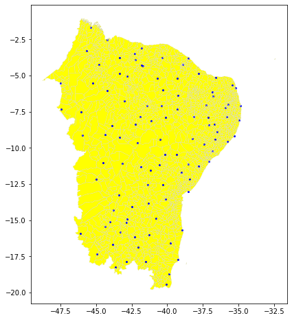

```python
fig, ax = plt.subplots(figsize=(8, 8)) #Building the figure

sudene_geo_info.plot(ax=ax, color = "yellow") #SUDENE map
geodf_indicators.intersection(sudene_geo_info.unary_union).plot(ax=ax, color = "blue", markersize=4) #Station
sudene_geo_info.boundary.plot(ax=ax,color = "lightgray", linewidth=0.2) #Borders dividing the municipality
```

## Interpolation of weather data

$$\hat {\text{I}} = \frac{{\text{I}}_{1}{\frac{1}{\text{distance}_{1}^{2}}} + {\text{I}}_{2}{\frac{1}{\text{distance}_{2}^{2}}} + {\text{I}}_{3}{\frac{1}{\text{distance}_{3}^{2}}} + {\text{I}}_{4}{\frac{1}{\text{distance}_{4}^{2}}} + {\text{I}}_{5}{\frac{1}{\text{distance}_{5}^{2}}}}{\frac{1}{\text{distance}_{1}^{2}} + \frac{1}{\text{distance}_{2}^{2}} + \frac{1}{\text{distance}_{3}^{2}} + \frac{1}{\text{distance}_{4}^{2}} + \frac{1}{\text{distance}_{5}^{2}}}$$

```python
#We will start by converting the coordinate system of both GeoDataFrames
geodf_indicators = geodf_indicators.to_crs('+proj=cea')
sudene_geo_info = sudene_geo_info.to_crs('+proj=cea')
```

The logic we use to identify the five closest stations is exemplified below:

```python
#Note that we use the distance to the city center.
geodf_indicators.geometry.distance(sudene_geo_info.centroid[0]).sort_values()[0:5]
```

```
index
82280     17253.982532
82382    166038.470792
82198    166510.336163
82376    196864.659707
82460    211205.409682
dtype: float64
```

```python
#Empty columns that will receive the data
sudene_geo_info["MEDIA_PREC_ANUAL"] = ""
sudene_geo_info["Aridity Index"] = ""
sudene_geo_info["dias_s_chuv"] = ""
```

To interpolate the data, we will use a loop to pass to whole cities inside our DF. Inside the loop, we will need to create a data frame intermediary to facilitate our calculations. We will show the intermediary DF logic below:

**Note:** In the code below, we are exemplifying the city in the zero position index. However, in the loop, we will change it to go through whole towns.

```python
##We will concatenate a DF informing the distances with one informing the values of the indicators.
pd.concat([pd.DataFrame(geodf_indicators.geometry.distance(sudene_geo_info.centroid[0]).sort_values()[0:5],
                        columns = ['DISTANCIA']), #DF informing the distances
           geodf_indicators. #DF informing the values of the indicators
           loc[geodf_indicators. #Here notice that we are locating the five closest stations.
               geometry.
               distance(sudene_geo_info.
                        centroid[0]).
               sort_values()[0:5].
               index][["MEDIA_PREC_ANUAL",
                       "Aridity Index",
                       "dias_s_chuv"]]],axis=1)
```

| index | DISTANCIA | MEDIA_PREC_ANUAL | Aridity Index | dias_s_chuv |
| --- | --- | --- | --- | --- |
| 82280 | 17253.982532 | 2202.376667 | 1.420048 | 215.900000 |
| 82382 | 166038.470792 | 1675.980000 | 1.077462 | 234.600000 |
| 82198 | 166510.336163 | 2200.643333 | 1.597558 | 196.526316 |
| 82376 | 196864.659707 | 1837.043333 | 1.029724 | 209.450000 |
| 82460 | 211205.409682 | 1814.726667 | 1.030145 | 222.636364 |

**Now let's go through the loop**

- First, we created the intermediate DF.
- Second, in this DF, we will add a column with the value of the weights used in our average.
- Third, we will calculate the average powered by the weights for each indicator.
- Finally, we will empty the intermediate DF before restarting the loop process again.
- It is worth mentioning that this code takes a little while to be executed entirely, as there are many cities in our database. So we added a time marker at the beginning of the code and another at the end so you can see how long it will take on your computer (in mine, it takes an average of 10 minutes).

```python
print(datetime.datetime.now().time()) #Time marker

for i in list(range(0,len(sudene_geo_info))): ##For each city/index

    ##Creating an intermediate DF
    df_inter = pd.concat([pd.DataFrame(geodf_indicators.
                                       geometry.
                                       distance(sudene_geo_info.centroid[i]).
                                       sort_values()[0:5],
                                       columns = ['DISTANCIA']),
                          geodf_indicators.
                          loc[geodf_indicators.
                              geometry.
                              distance(sudene_geo_info.
                                       centroid[i]).
                              sort_values()[0:5].
                              index][["MEDIA_PREC_ANUAL",
                                      "Aridity Index",
                                      "dias_s_chuv"]]],axis=1)

    ##Creating the weights for the interpolation
    df_inter['PESOS'] = (1/(df_inter['DISTANCIA']**2))

    ##Average annual precipitation
    sudene_geo_info.loc[i,"MEDIA_PREC_ANUAL"] = ((df_inter["MEDIA_PREC_ANUAL"]*
                                                  df_inter["PESOS"]).sum())/df_inter["PESOS"].sum()

    ##Aridity Index
    sudene_geo_info.loc[i,"Aridity Index"] = ((df_inter["Aridity Index"]*
                                               df_inter["PESOS"]).sum())/df_inter["PESOS"].sum()

    ##Days without rain
    sudene_geo_info.loc[i,"dias_s_chuv"] = ((df_inter["dias_s_chuv"]*
                                             df_inter["PESOS"]).sum())/df_inter["PESOS"].sum()

    ##Cleaning the intermediate DF
    df_inter = None

print(datetime.datetime.now().time()) #Time marker
```

```
12:30:05.345139
12:40:24.659116
```

```python
#Result!
sudene_geo_info.head()
```

|  | NM_MUNICIP | geometry | MEDIA_PREC_ANUAL | Aridity Index | dias_s_chuv |
| --- | --- | --- | --- | --- | --- |
| 0 | RAPOSA | MULTIPOLYGON (((-4900312.633 -266111.261, -490... | 2191.66 | 1.41291 | 215.89 |
| 1 | HELIÓPOLIS | POLYGON ((-4258712.453 -1175830.182, -4257557.... | 719.342 | 0.573615 | 224.394 |
| 2 | ABAIARA | POLYGON ((-4343388.924 -805328.762, -4343360.3... | 1447.17 | 0.847705 | 271.244 |
| 3 | RECIFE | POLYGON ((-3896149.463 -874106.485, -3896129.8... | 2259.07 | 1.55885 | 143.435 |
| 4 | ABAÍRA | POLYGON ((-4636147.490 -1444764.175, -4636099.... | 903.503 | 0.603956 | 256.928 |

**Convertendo os valores de string para float**

```python
sudene_geo_info["MEDIA_PREC_ANUAL"] = sudene_geo_info["MEDIA_PREC_ANUAL"].astype(float)
sudene_geo_info["Aridity Index"] = sudene_geo_info["Aridity Index"].astype(float)
sudene_geo_info["dias_s_chuv"] = sudene_geo_info["dias_s_chuv"].astype(float)
```

## Maps

Now we will use the information from our data frame "sudene_geo_info" to build colormaps that allow us to analyze the semiarid condition of cities.

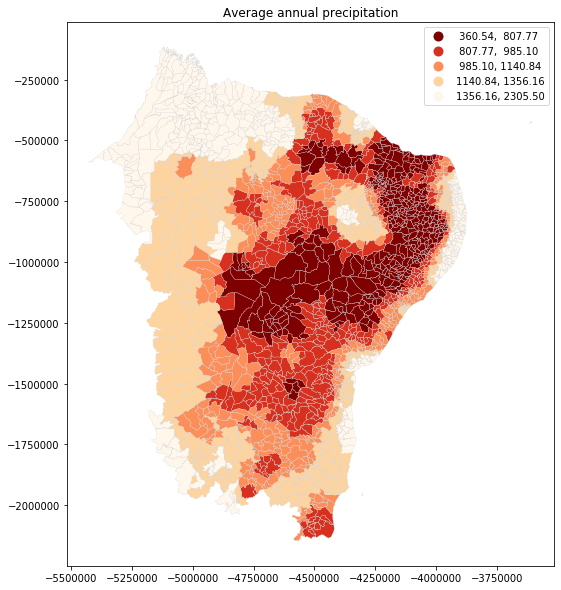

```python
##Average annual precipitation
fig, ax = plt.subplots(figsize=(10, 10)) #Building the figure

#Colormaps
sudene_geo_info.plot(ax=ax,
                     column = "MEDIA_PREC_ANUAL",
                     cmap = plt.cm.get_cmap("OrRd").reversed(), #The redder the more semiarid
                     scheme='quantiles',
                     k=5,
                     legend=True)

#Highlighting at the borders of cities
sudene_geo_info.boundary.plot(ax=ax,color = "lightgray", linewidth=0.2)

#Title
plt.title("Average annual precipitation")
```

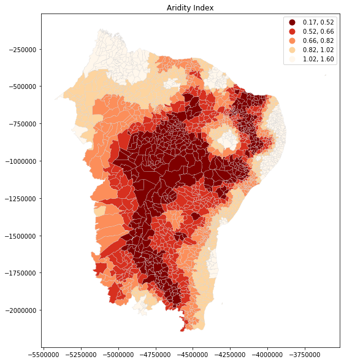

```python
##Aridity Index
fig, ax = plt.subplots(figsize=(10, 10)) #Building the figure

#Colormaps
sudene_geo_info.plot(ax=ax,
                     column = "Aridity Index",
                     cmap = plt.cm.get_cmap("OrRd").reversed(), #The redder the more semiarid
                     scheme='quantiles',
                     k=5,
                     legend=True)

#Highlighting at the borders of cities
sudene_geo_info.boundary.plot(ax=ax,color = "lightgray", linewidth=0.2)

#Title
plt.title("Aridity Index")
```

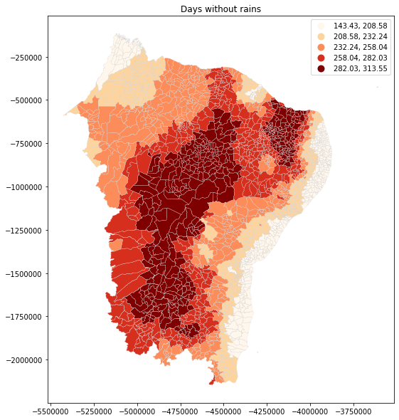

```python
##Days without rains
fig, ax = plt.subplots(figsize=(10, 10)) #Building the figure

#Colormaps
sudene_geo_info.plot(ax=ax,
                     column = "dias_s_chuv",
                     # Here we do not use the "reversed" because the more days without rain,
                     # the more semiarid the climate
                     cmap = plt.cm.get_cmap("OrRd"), #The redder the more semiarid
                     scheme='quantiles',
                     k=5,
                     legend=True)

#Highlighting at the borders of cities
sudene_geo_info.boundary.plot(ax=ax,color = "lightgray", linewidth=0.2)

#Title
plt.title("Days without rains")
```